# Lab 02

## Instructions

The format for this lab will mirror the majority of labs for this semester. I have a section here which loads in various libraries (if some are new, there will also be code to install them) and then loads a dataset of interest. Your goal is to predict the value of the third column (which will be missing on the test set) using the techniques we have learned so far. In this case, please restrict yourself to univariate linear regressions.

The lab should be written as short code snippets with surrounding text. The text should be in full sentences and should fully describe what and why you are running the code you are running. When there are results, you should also give a sentence or two describing them.

Make sure to include at a minimum several plots and argue for why you chose your final model.

You may not share code with other students prior to the submission of each lab. However, discussing the labs amongst other students is allowed. Also, copying and pasting my code from class or prior submissions you made is **not** considered plagiarism and is in fact highly encouraged. With permission, I may occasionally post student-solutions to past labs. These are also fair game for copying code from (though please do not excessively copy the expository text). If in doubt, please ask me before submitting results.

## Set up

Your first step should be to read in the following libraries:

```r
library(readr)
library(dplyr)
```

```r
library(ggplot2)
library(viridis)
```

And to load the abalone dataset:

```r
abalone <- read_csv("https://statsmaths.github.io/ml_data/abalone.csv")
```

An abalone is a particular type of shellfish; I find it rather funny looking:

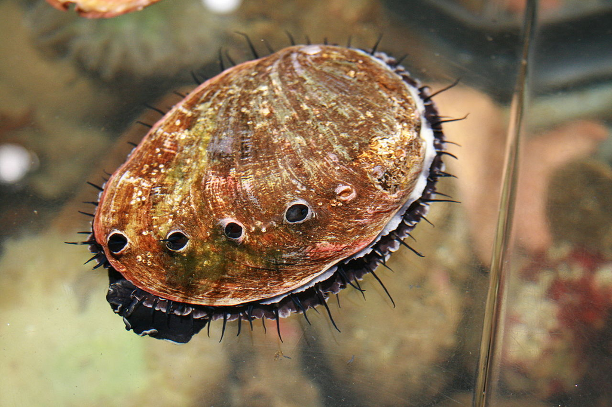

Your goal is to use physical characteristics from a set of abalone to predict the shellfish’s age.

Your code and text should go in the section below (feel free to create sub-sections with the `###` command at the start of line, though please note that this is not required):

## Lab 02

The goal here is to predict the age variable. We see that this variable is roughly normally distributed with a mode around 10 years:

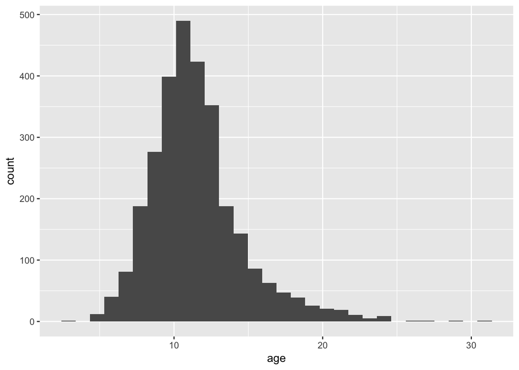

```r
qplot(age, data = abalone)
```

Looking at a number of variables, it visually appears that the `sheel_weight` variable is the most predictive. That is, points deviate from the line the least:

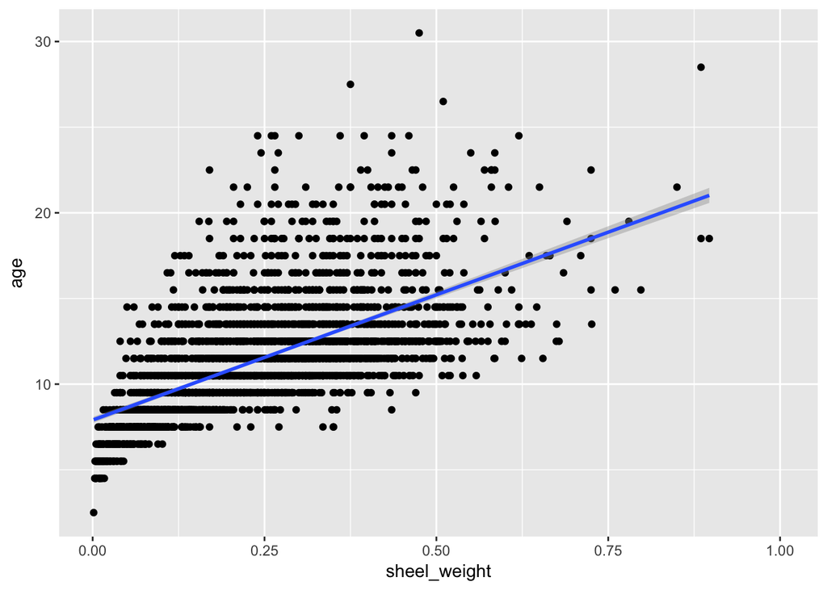

```r
qplot(sheel_weight, age, data = abalone) +
  geom_smooth(method = "lm")
```

(NOTE: Usually, I would use some proper validation techniques to evaluate this model, but for now a visual argument is fine. Also, I may be wrong about which variable looks the most predictive; it is just a feeling after looking at a few plots. Other choices are not necessarily wrong.)

As we only know how to do univariate models at this point, I will just fit a univariate model using `sheel_weight` to predict age.

```r
model <- lm(age ~ sheel_weight, data = abalone)
abalone$age_pred <- predict(model, newdata = abalone)
```

Usually I would finish by showing the RMSE of my prediction on the training set, but as mentioned above we haven’t covered that yet so there is not much more to say.

## Submission

The code below assumes that you have adding a prediction named `age_pred` to every row of the `abalone` dataset.

```r
submit <- select(abalone, obs_id, age_pred)
write_csv(submit, "class02_submit.csv")
```

Now, upload this file (ends with “.Rmd”), the HTML output (ends with “.nb.html”), and the csv file to GitHub.